# Shoesoles Database

Guillermo Basulto-Elias

2017-05-22

## Shoeprints Matching

There are several problems related to shoeprints in a crime scene. It is important to distinguish keep in mind what problem is being solved.

1. Given a shoeprint in a crime scene we want to determine whether it was generated with a given shoe.
2. Determine the model of a shoeprint. This can be done by looking for the appropriate pattern in a database of shoesoles images.

### Shoeprints from Scanner

We can generate our own set of shoe-soles using the scanner available. The following image is a sample of a shoeprint obtained with the Everspry scanner.

```
## The image size is  4563 x 2083 .
```

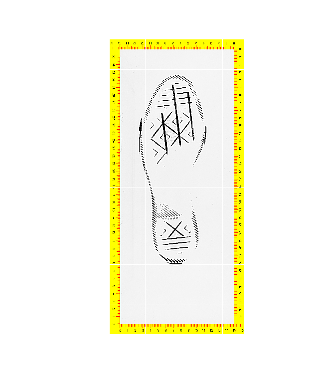

### Processing

It is convenient to invert the colors, since we are going to integrate out values and darker pixels are closer to value zero. Moreover, the each image should be transformed to gray scale.

In Ubuntu:

1. First, we converted all the tiff files to grayscale using the following command line in Ubuntu’s terminal.

`for img in $(find . -iname '*.tiff'); do echo -n "Converting $img"; convert -colorspace GRAY $img $img && echo ' [Done]'; done`

2. Invert the colors of the images to replace the white areas with black.

`for img in $(find . -iname '*.tiff'); do echo -n "Inverting $img"; convert -negate $img $img && echo ' [Done]'; done`

[figure not shown]

### Pilot Database

There are images of 233 shoe-soles. Several subjects tried different models of shoes and obtained (usually) five replicates of every combination of individual-shoe model-foot. This information is coded in the filename, e.g., “spl_02R_04.tiff” corresponds to the 4th replicate of the right foot of the model 02, which was worn by the subject ‘spl’.

```
## [1] "spl_02R_03.tiff" "hri_01R_01.tiff" "spl_07L_03.tiff" "hri_01R_02.tiff"
## [5] "hri_05L_03.tiff" "spl_01R_02.tiff"
```

### Features Extraction

A relatively easy standard method to extract features from an image is to compute the so-called Hu’s invariant moments. This is a method that can be applied to any image, but it apparently works well on shoeprints (cf. AlGarni & Hamiane (2008)).

| phi1 | phi2 | phi3 | phi4 | phi5 | phi6 | phi7 | phi8 |
| --- | --- | --- | --- | --- | --- | --- | --- |
| 3.877962 | 10.854539 | 15.201582 | 12.479111 | 171.87519 | 40.46222 | 70.893361 | -3.6457639 |
| 3.351600 | 8.221277 | 5.663187 | 3.605451 | 16.28173 | 10.11633 | 1.342011 | -1.0642592 |
| 4.002636 | 11.844037 | 13.706222 | 11.695933 | 148.05757 | 40.08066 | 50.362957 | -1.8536553 |
| 3.696992 | 9.893825 | 9.560384 | 7.270398 | 60.57740 | 21.74562 | 43.384843 | -3.5391526 |
| 4.332113 | 14.615750 | 5.228813 | 3.658099 | 15.96030 | 12.90236 | 10.785574 | -2.6977989 |
| 3.616304 | 9.397682 | 10.516973 | 9.360379 | 92.84749 | 28.65696 | -69.998180 | 0.7369421 |

## Plots with Pilot Database

```
## Unique combinations of person-shoemodel
```

```
##  [1] "conv_01" "conv_02" "conv_03" "conv_04" "hri_01"  "hri_02"  "hri_03"
##  [8] "hri_04"  "hri_05"  "hri_06"  "hri_07"  "hri_08"  "hri_09"  "mty_01"
## [15] "mty_02"  "mty_03"  "rob_01"  "spl_01"  "spl_02"  "spl_03"  "spl_04"
## [22] "spl_05"  "spl_06"  "spl_07"
```

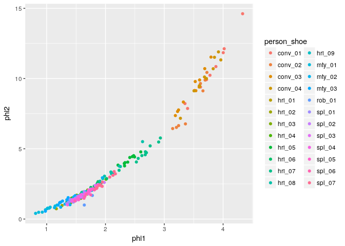

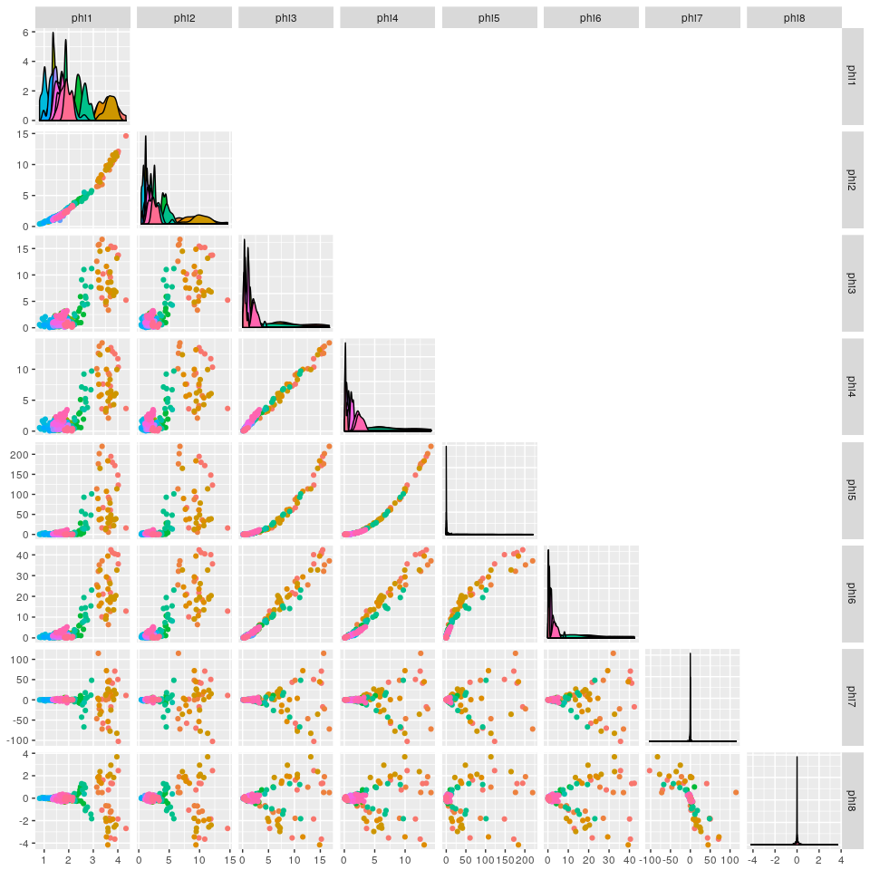

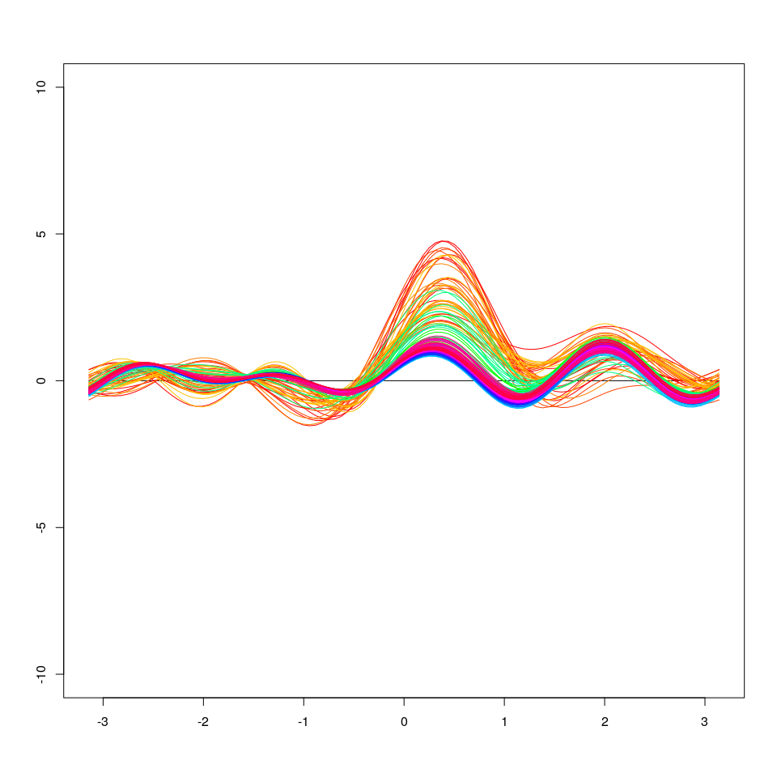